# Can Money and Population Size Buy Happiness?

## 1. Introduction

Happiness is an important factor in so many facets of our lives and is influenced by so many different factors that it is hard to fully grasp. However, the Happiness Report has taken on this task and created a happiness score for most countries based on a variety of factors such as freedom to make life choices, social support and many more. We wanted to look and see if the scores given by this organization had any correlation to other factors that may not have been considered within the original report.

### b. Quick description of the datasets

Since the report uses data from 2019-2021, we chose to look at the change in total population and GDP between 2019-2021. To do this we looked at total population and GDP per country at both 2019 and 2021 and will find the difference between the two values to then compare to the happiness score of their respective country.

Each unique row in the datasets represent a specific country and every variable apart from the countries are numerical while the countries are categorical. Finally, we expect to join our 3 datasets together through the key ‘Country’.

```r
# Upload data sets from folder
happiness <- read_csv("Country Happiness Data.csv")
gdp <- read_csv("GDP.csv")
population <- read_csv("Population.csv")

## Take a look
glimpse(happiness)
```

```
## Rows: 147
## Columns: 12
## $ RANK                                         <dbl> 146, 90, 96, 57, 82, 12, …
## $ Country                                      <chr> "Afghanistan", "Albania",…
## $ `Happiness score`                            <dbl> 2.404, 5.199, 5.122, 5.96…
## $ `Whisker-high`                               <dbl> 2.469, 5.321, 5.215, 6.09…
## $ `Whisker-low`                                <dbl> 2.339, 5.076, 5.030, 5.84…
## $ `Dystopia (1.83) + residual`                 <dbl> 1.263, 1.718, 1.744, 1.89…
## $ `Explained by: GDP per capita`               <dbl> 0.758, 1.439, 1.363, 1.59…
## $ `Explained by: Social support`               <dbl> 0.000, 0.646, 0.970, 1.10…
## $ `Explained by: Healthy life expectancy`      <dbl> 0.289, 0.719, 0.643, 0.66…
## $ `Explained by: Freedom to make life choices` <dbl> 0.000, 0.511, 0.146, 0.55…
## $ `Explained by: Generosity`                   <dbl> 0.089, 0.138, 0.106, 0.08…
## $ `Explained by: Perceptions of corruption`    <dbl> 0.005, 0.028, 0.150, 0.08…
```

```r
glimpse(gdp)
```

```
## Rows: 219
## Columns: 6
## $ `Country Name`  <chr> "Afghanistan", "Albania", "Algeria", "American Samoa",…
## $ `Country Code`  <chr> "AFG", "ALB", "DZA", "ASM", "AND", "AGO", "ATG", "ARG"…
## $ `Series Name`   <chr> "GDP (current LCU)", "GDP (current LCU)", "GDP (curren…
## $ `Series Code`   <chr> "NY.GDP.MKTP.CN", "NY.GDP.MKTP.CN", "NY.GDP.MKTP.CN", …
## $ `2019 [YR2019]` <dbl> 1.469596e+12, 1.691903e+12, 2.050106e+13, 6.470000e+08…
## $ `2021 [YR2021]` <dbl> 1.232858e+12, 1.889839e+12, 2.202150e+13, 7.090000e+08…
```

```r
glimpse(population)
```

```
## Rows: 201
## Columns: 4
## $ Rank    <dbl> 38, 138, 35, 45, 200, 31, 140, 195, 55, 98, 91, 176, 154, 8, 1…
## $ Country <chr> "Afghanistan", "Albania", "Algeria", "Angola", "Antigua and Ba…
## $ `2019`  <dbl> 37769499, 2873884, 42705369, 32353588, 92117, 44745520, 282060…
## $ `2021`  <dbl> 40099462, 2854710, 44177969, 34503774, 93220, 45276780, 279097…
```

```r
# observations
happiness %>%
  summarize(n_happiness = n_distinct(Country))
```

```
## # A tibble: 1 × 1
##   n_happiness
##         <int>
## 1         147
```

```r
gdp %>%
  summarize(n_gdp = n_distinct(`Country Name`))
```

```
## # A tibble: 1 × 1
##   n_gdp
##   <int>
## 1   219
```

```r
population %>%
  summarize(n_pop = n_distinct(Country))
```

```
## # A tibble: 1 × 1
##   n_pop
##   <int>
## 1   201
```

Before joining our 3 datasets there were 147 observations for the happiness dataset, 201 observations for the total population dataset, and 219 observations of the GDP dataset.

### c. Define a research question

We wanted to look and see if the scores given by this organization had any correlation to other factors that may not have been considered within the original report. Our research questions are:

1. Does the GDP between 2021 and 2019 have a relationship with a country’s happiness score?
2. Does a country’s total population change between 2021 and 2019 have an effect on their happiness score?

We expect to see a positive linear relationship between GDP and happiness score while we expect to see a normal distribution when it comes to total population and happiness score.

## 2. Tidying Part 1

In order to join together the 3 datasets we first had to create new columns for our ‘gdpdiff’ and ‘popdiff’ as well as rename a few columns to make them more accurate and easily called.

```r
# creating a new column and tidying population data into a new dataset
pop1 <- population %>%
  rename(pop.2019 = `2019`,
         pop.2021 = `2021`) %>%
  mutate(popdiff = pop.2021 - pop.2019)

# renaming variable names and calculating gdp difference
gdp1 <- gdp %>%
  rename(gdp.2019 = `2019 [YR2019]`,
         gdp.2021 = `2021 [YR2021]`) %>%
  mutate(gdpdiff = gdp.2021 - gdp.2019)
```

## 3. Joining/Merging

We used ‘anti_join’ to look at what countries did not match in order to figure out what countries had different names between the datasets. We renamed a few countries because the names for each specific country were not the same and in order for the ‘left_join’ to work the names needed to be the same.

```r
# checking if there are matches for all countries between happiness and 'gdp1'
anti_join(happiness, gdp1, by = c("Country" = "Country Name"))
```

```
## # A tibble: 12 × 12
##     RANK Country Happi…¹ Whisk…² Whisk…³ Dysto…⁴ Expla…⁵ Expla…⁶ Expla…⁷ Expla…⁸
##    <dbl> <chr>     <dbl>   <dbl>   <dbl>   <dbl>   <dbl>   <dbl>   <dbl>   <dbl>
##  1    99 Congo      5.08    5.24    4.92   2.66    0.95    0.405   0.355   0.431
##  2   129 Egypt      4.29    4.38    4.20   0.856   1.39    0.732   0.548   0.469
##  3   125 Eswati…    4.40    4.61    4.18   1.69    1.27    0.786   0.197   0.259
##  4    93 Gambia     5.16    5.41    4.92   2.53    0.785   0.621   0.369   0.367
##  5   110 Iran       4.89    5.00    4.78   1.43    1.41    0.741   0.642   0.281
##  6    88 Ivory …    5.24    5.38    5.08   2.65    1.09    0.442   0.322   0.451
##  7    79 North …    5.47    5.61    5.32   1.08    1.82    0.888   0.819   0.523
##  8   122 Palest…    4.48    4.66    4.3    1.37    1.15    0.957   0.521   0.336
##  9    80 Russia     5.46    5.52    5.39   1.49    1.68    1.10    0.586   0.401
## 10    26 Taiwan…    6.51    6.60    6.43   2.00    1.90    1.10    0.733   0.542
## 11   112 Turkey     4.74    4.84    4.64   1.06    1.71    0.865   0.702   0.209
## 12   147 xx        NA      NA      NA     NA      NA      NA      NA      NA
## # … with 2 more variables: `Explained by: Generosity` <dbl>,
## #   `Explained by: Perceptions of corruption` <dbl>, and abbreviated variable
## #   names ¹`Happiness score`, ²`Whisker-high`, ³`Whisker-low`,
## #   ⁴`Dystopia (1.83) + residual`, ⁵`Explained by: GDP per capita`,
## #   ⁶`Explained by: Social support`, ⁷`Explained by: Healthy life expectancy`,
## #   ⁸`Explained by: Freedom to make life choices`
```

```r
# renaming countries in 'gdp1' to match and join together into new dataset
gdp2 <- gdp1 %>%
  mutate(`Country Name` = recode(`Country Name`,
                                  'Congo, Rep.' = 'Congo',
                                  'Egypt, Arab Rep.' = 'Egypt',
                                  'Eswatini' = 'Eswatini, Kingdom of',
                                  'Gambia, The' = 'Gambia',
                                  'Iran, Islamic Rep.' = 'Iran',
                                  "Cote d'Ivoire" = "Ivory Coast",
                                  'Russian Federation' = 'Russia',
                                  'Turkiye' = 'Turkey'))

# checking if there are matches for all countries between happiness and 'pop1'
anti_join(happiness, pop1, by = "Country")
```

```
## # A tibble: 12 × 12
##     RANK Country Happi…¹ Whisk…² Whisk…³ Dysto…⁴ Expla…⁵ Expla…⁶ Expla…⁷ Expla…⁸
##    <dbl> <chr>     <dbl>   <dbl>   <dbl>   <dbl>   <dbl>   <dbl>   <dbl>   <dbl>
##  1    18 Czechia    6.92    7.03    6.81   2.26     1.82   1.26    0.715   0.66
##  2   125 Eswati…    4.40    4.61    4.18   1.69     1.27   0.786   0.197   0.259
##  3    81 Hong K…    5.42    5.50    5.35   0.642    1.96   0.954   0.942   0.4
##  4    88 Ivory …    5.24    5.38    5.08   2.65     1.09   0.442   0.322   0.451
##  5    32 Kosovo     6.46    6.57    6.34   2.63     1.36   0.949   0.569   0.599
##  6    62 Moldova    5.86    5.95    5.77   2.14     1.42   1.01    0.597   0.561
##  7    79 North …    5.47    5.61    5.32   1.08     1.82   0.888   0.819   0.523
##  8    89 North …    5.20    5.30    5.10   1.46     1.50   0.863   0.637   0.488
##  9   122 Palest…    4.48    4.66    4.3    1.37     1.15   0.957   0.521   0.336
## 10    80 Russia     5.46    5.52    5.39   1.49     1.68   1.10    0.586   0.401
## 11    26 Taiwan…    6.51    6.60    6.43   2.00     1.90   1.10    0.733   0.542
## 12   147 xx        NA      NA      NA     NA       NA     NA      NA      NA
## # … with 2 more variables: `Explained by: Generosity` <dbl>,
## #   `Explained by: Perceptions of corruption` <dbl>, and abbreviated variable
## #   names ¹`Happiness score`, ²`Whisker-high`, ³`Whisker-low`,
## #   ⁴`Dystopia (1.83) + residual`, ⁵`Explained by: GDP per capita`,
## #   ⁶`Explained by: Social support`, ⁷`Explained by: Healthy life expectancy`,
## #   ⁸`Explained by: Freedom to make life choices`
```

```r
# renaming countries in 'pop1' to match and join together into new dataset
pop2 <- pop1 %>%
  mutate(Country = recode(Country,
                          'Czech Republic' = 'Czechia',
                          'China, Hong Kong SAR' = 'Hong Kong S.A.R. of China',
                          'Côte d\'Ivoire' = 'Ivory Coast',
                          'TYFR Macedonia' = 'North Macedonia',
                          'State of Palestine' = 'Palestinian Territories',
                          'Russian Federation' = 'Russia',
                          'Taiwan' = 'Taiwan Province of China'))

# joining 'gdp2' into 'happiness' and putting it into 'happiness1'
happiness1 <- left_join(happiness, gdp2, by = c("Country" = "Country Name"))

# joining ‘pop2’ into ‘happiness1’ and replace new data set into ‘happiness1’
happiness1 <- left_join(happiness1, pop2, by = "Country")
```

## 4. Tidying Part 2

After joining all the datasets, we needed to tidy some more!

```r
# tidying joined data into new dataset
happiness2 <- happiness1 %>%
  select(-c(Rank, `Series Name`, `Series Code`)) %>%
  pivot_longer(cols = c('gdp.2019', 'gdp.2021', 'pop.2019', 'pop.2021')) %>%
  separate(name, into = c("type", "year")) %>%
  pivot_wider(names_from = type,
              values_from = value) %>%
  na.omit()
```

In order to tidy our data set we split the columns ‘gdp.2019’, ‘gdp.2021’, ‘pop.2019’, and ‘pop.2021’ into new columns based using ‘pivot_longer’ and ‘pivot_wider’. First these original columns were split apart based on year and value and then renamed into type and year using ‘pivot_longer’ and then the ‘type’ columns were split into ‘gdp’ and ‘pop’ using ‘pivot_wider’. NA values were then removed from the new tidied ‘happiness 2’ dataset.

## 5. Wrangling

```r
# pulling random countries and saving them into a data set
set.seed(55)
happiness3 <- sample_n(happiness2, 55)

# selecting specific variables and arranging 'Happiness score' highest to lowest
happiness3 %>%
  select(year, Country, popdiff, gdpdiff, `Happiness score`) %>%
  filter(year == 2021) %>%
  arrange(desc(`Happiness score`))
```

```
## # A tibble: 34 × 5
##    year  Country        popdiff gdpdiff `Happiness score`
##    <chr> <chr>            <dbl>   <dbl>             <dbl>
##  1 2021  Denmark          58363 1.93e11              7.64
##  2 2021  Iceland           9560 2.07e11              7.56
##  3 2021  Netherlands    7268943 4.33e10              7.42
##  4 2021  Israel          292139 1.43e11              7.36
##  5 2021  New Zealand     170694 2.93e10              7.2
##  6 2021  United States  2677953 1.93e12              6.98
##  7 2021  United Kingdom  502381 3.84e10              6.94
##  8 2021  Slovenia          6508 3.67e 9              6.63
##  9 2021  Brazil         2543345 1.29e12              6.29
## 10 2021  Kazakhstan     8963713 1.44e13              6.23
## # … with 24 more rows
```

```r
# creating a new categorical variable and summarizing some variables
happiness3 %>%
  mutate(highhappy = ifelse(`Happiness score` <= 5,
    "low score", "high score")) %>%
  group_by(year) %>%
  summarize(n = length(Country),
            highscore = sum(highhappy == "high score"),
            lowscore = sum(highhappy == "low score"),
            popmedian = median(pop),
            gdpmedian = median(gdp),
            gdpdiffsd = sd(gdpdiff, na.rm = T),
            popdiffsd = sd(popdiff, na.rm = T))
```

```
## # A tibble: 2 × 8
##   year      n highscore lowscore popmedian     gdpmedian gdpdiffsd popdiffsd
##   <chr> <int>     <int>    <int>     <dbl>         <dbl>     <dbl>     <dbl>
## 1 2019     21        14        7 10232753  2238348000000   1.28e13  4668827.
## 2 2021     34        23       11 22002834. 2937585017000   6.76e15  3473672.
```

After pulling a random sample to get a more manageable sample size the variables: ‘year’, ‘Country’, ‘popdiff’, ‘gdpdiff’, and Happiness score were selected and then filtered by year. Happiness score was then divided into low and high based on the happiness scale of 1-10 with 5 and below being classified as low and a score greater than 5 being classified as high. ‘summarize’ was used to examine the number of both low and high scores in 2019 and 2021 as well as the median and standard deviation for both population and GDP in 2019 and 2021. This shows us that over time the median GDP and population goes up over time along with the number of low scores. This signifies that there may be an inverse relationship between population/GDP and happiness scores.

## 6. Visualizations

### a. Graph 1: Happiness Frequency Plot

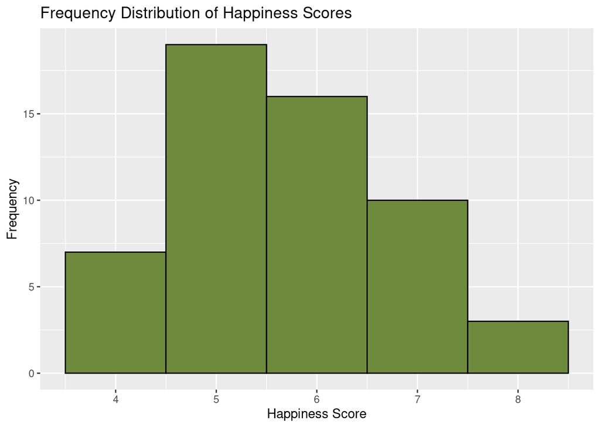

```r
# create frequency plot for happiness score
happiness3 %>%
  ggplot(aes(x = `Happiness score`)) +
  geom_histogram(color = "black", fill = "darkolivegreen4", binwidth = 1) +
  labs(x = "Happiness Score",
       y = "Frequency",
       title = "Frequency Distribution of Happiness Scores") +
  scale_x_continuous(breaks = seq(0,9,1))
```

### b. Graph 2: Population Difference Frequency Plot

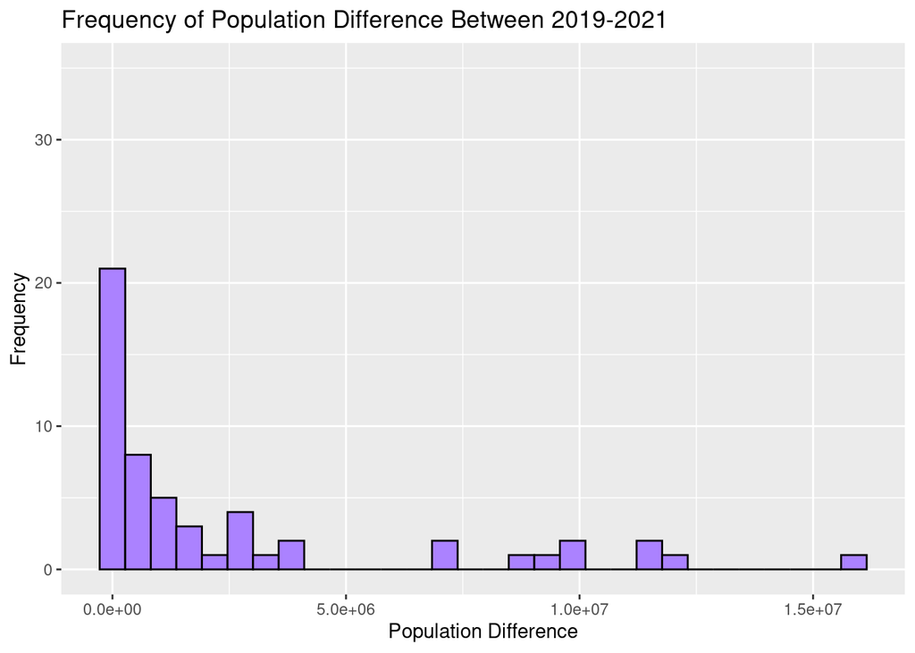

```r
# create frequency plot for population difference
happiness3 %>%
  ggplot(aes(x = popdiff)) +
  geom_histogram(color = "black", fill = "mediumpurple1", bins = 30) +
  labs(x = "Population Difference",
       y = "Frequency",
       title = "Frequency of Population Difference Between 2019-2021") +
  ylim(0,35)
```

The graph shows a frequency distribution for population change between 2019-21. It shows that most countries either experienced no population change or a negligible amount. However, more countries gained population than lost population as there are relatively more countries with population gains than losses and therefore shows a relatively right skewed plot.

### c. Graph 3: Happiness based on GDP per capita vs. GDP Difference

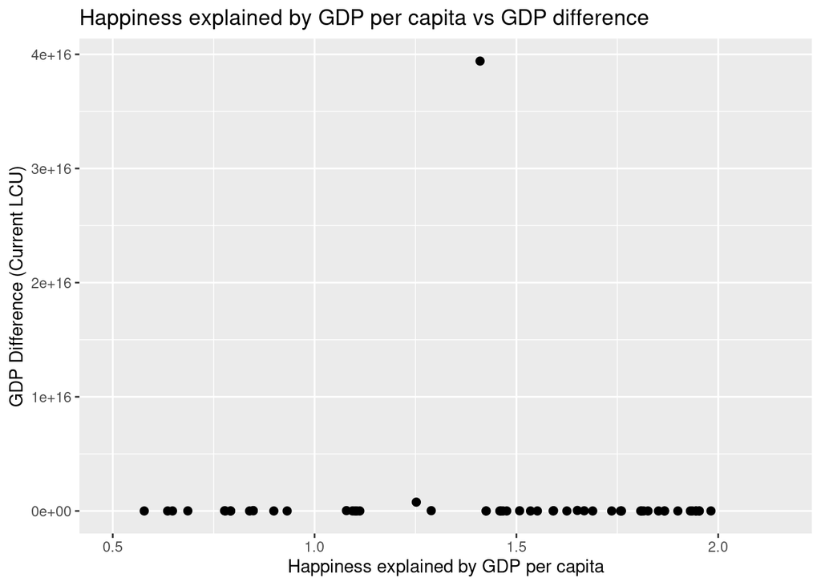

```r
# create plot for happiness score explained by gdp per capita vs GDP difference
happiness3 %>%
  ggplot(aes(x = `Explained by: GDP per capita`, y = gdpdiff)) +
  geom_point(size = 2) +
  labs(x = "Happiness explained by GDP per capita",
       y = "GDP Difference (Current LCU)",
       title = "Happiness explained by GDP per capita vs GDP difference") +
  xlim(0.5, 2.15)
```

The scatterplot above illustrates the relationship between GDP difference between 2019-21 and the portion of the happiness score explained by GDP per capita within this same time period. Surprisingly there seems to be no correlation between the two. Even as more of the happiness score is explained by GDP, indicating that more of the score was impacted by the country’s GDP, the GDP difference over the designated time period stayed mostly the same at 0. There do appear to be some outliers as more of the score is determined by GDP with a handful of countries showing a large growth in GDP, however there were not enough for it to be considered a proper relationship

### d. Graph 4: Comparison of GDP Difference and Population Difference

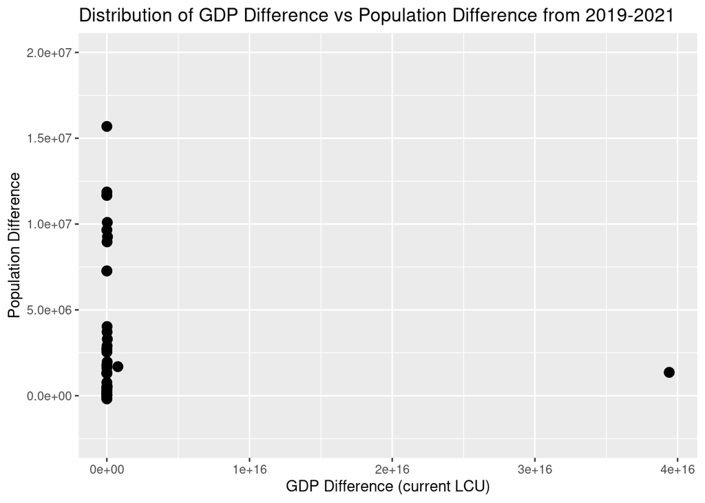

```r
# create plot for gdp difference vs population difference
happiness3 %>%
  ggplot(aes(x = gdpdiff, y = popdiff)) +
  geom_point(size = 3) +
  labs(x = "GDP Difference (current LCU)",
       y = "Population Difference",
       title = "Distribution of GDP Difference vs Population Difference from 2019-2021") +
  ylim(-2.5e+6,2e+7)
```

### e. Graph 5: Country, Happiness, and Population Changes

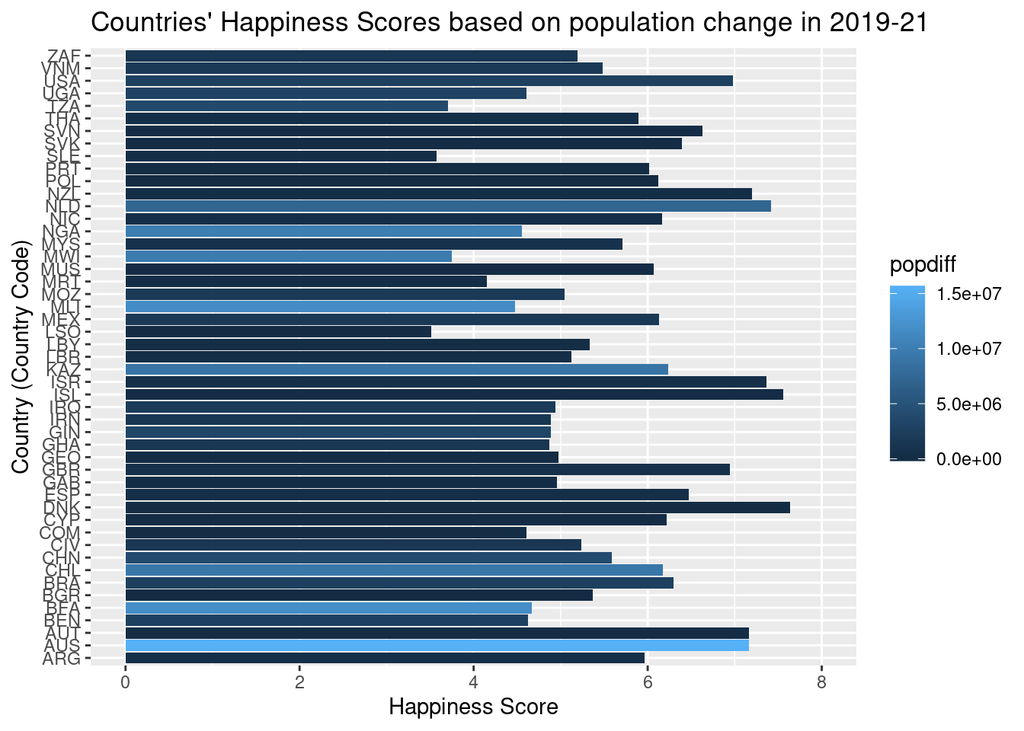

```r
# create plot for country, happiness score, and population difference
happiness3 %>%
  ggplot(aes(x = `Happiness score`, y = `Country Code`, fill = popdiff)) +
  geom_bar(position = "dodge", stat = "identity") +
  labs(x = "Happiness Score",
       y = "Country (Country Code)",
       title = "Countries' Happiness Scores based on population change in 2019-21") +
  xlim(0,8)
```

The histogram above shows each countries happiness score by the length of the countries respective bar length while showing the magnitude of the population difference between 2019-21. A larger happiness score represents a happier country while a lower score represents a less happy country. A lighter bar color corresponds to a greater population change while a darker bar color corresponds to a smaller population change. There does not appear to be any relationship between happiness score and population change per country. Countries with low population change appear both as countries with low and high happiness scores and the same can be said by countries with high happiness scores.

### f. Graph 6: Country, Happiness, and GDP Changes

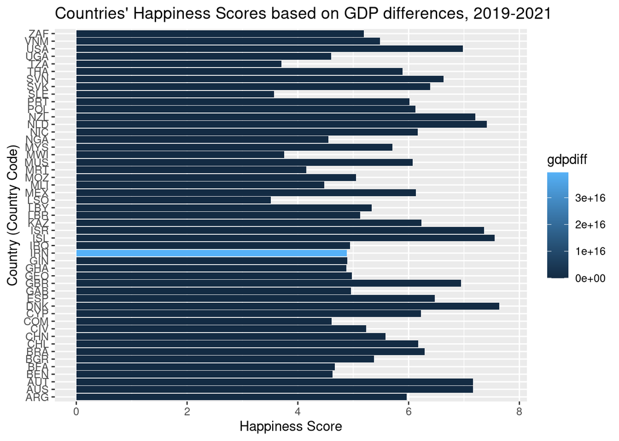

```r
# create plot for country, happiness score, and gdp difference
happiness3 %>%
  ggplot(aes(x = `Happiness score`, y = `Country Code`, fill = gdpdiff)) +
  geom_bar(position = "dodge", stat = "identity") +
  labs(x = "Happiness Score",
       y = "Country (Country Code)",
       title = "Countries' Happiness Scores based on GDP differences, 2019-2021") +
  xlim(0,7.75)
```

The histogram above shows each country’s happiness score by the length of the bar while the color represents the difference in GDP of that respective country between 2019-21. The darker the color of the bar represents a smaller or a loss in GDP while a lighter color represents a growth in GDP. Despite the varying happiness scores across countries there does not appear to be a relationship between GDP and happiness score. Most countries fall within a certain color range for GDP and the few outliers in color aren’t necessarily high or low in happiness score. Therefore based on this graph no relationship can be seen.

## 7. Discussion

This project overall was challenging especially in figuring out how to merge and tidy our datasets and even further challenging how to visualize our dataset in a constructive way. Experimenting with different visualizations was time consuming and required a lot of trial and error. From this process we learned the importance of tidying and how surprisingly hard it is to get graphs that look legible. For contributions Katelyn did a majority of the coding while Gavin did most of the writing, however both of us helped the other and bounced ideas off of each other.